# Hawk Classification

Kevin Greenberg

# Purpose

The goal of the hawks classification document is to compare different machine learning algorithms in their performance for classifiying different species of hawks. The data set has three different types of hawks, Coopers, Red-tailed, and Sharp-shinned hawks, with a variety of features/characterrists for each hawk. Using these characteristics, we will classify the species of hawks using the following algorithms:

One rule learner

K-nearest neighbor (KNN)

Decision tree

Boosted Decision tree

Support Vector Machines (SVM)

Also included are a couple Visualizations of the data, along with what fit indicies we will use, see Kappa, and how we Split the data. Lastly, if you want the just want to see the brief findings you can jump to the Comparing models.

```r
knitr::opts_chunk$set(echo = TRUE, cache = TRUE, comment = "", tidy = TRUE)

library(tidyverse)
library("OneR")
library(caret)
library(class)
library(gmodels)
library(C50)
library(kernlab)
library(ggalt)
library(ggfortify)
library(gridExtra)

hw <- read.csv("C:/Users/kevin/Desktop/Hawks/Hawks.csv")
hw$Species <- factor(hw$Species , levels = c("CH", "RT", "SS"),labels = c("Coopers", "Red-tailed", "Sharp-shinned"))
hw$Age <- factor(hw$Age , levels = c("A", "I"),labels = c("Adult", "Immature"))
```

### Data preprocessing

First the data was reduced to the main features that were used to identify the species of hawks. The features were Wing length, Weight, Culmen length (beak), hallux length(backward facing talon)).

```r
hw1 <- hw[,c(8, 11:14)]
```

In addition, the four features having missing values, so I did mean imputation(given the small amount of NA’s in the selected features; <=1%)

```r
for(i in 1:ncol(hw1)){
  hw1[is.na(hw1[,i]), i] <- mean(hw1[,i], na.rm = TRUE)
}
summary(hw1) # double check NA's are imputed
```

```
          Species         Wing           Weight           Culmen
 Coopers      : 70   Min.   : 37.2   Min.   :  56.0   Min.   : 8.6
 Red-tailed   :577   1st Qu.:202.0   1st Qu.: 186.8   1st Qu.:12.8
 Sharp-shinned:261   Median :370.0   Median : 967.0   Median :25.5
                     Mean   :315.6   Mean   : 772.1   Mean   :21.8
                     3rd Qu.:390.0   3rd Qu.:1120.0   3rd Qu.:27.3
                     Max.   :480.0   Max.   :2030.0   Max.   :39.2
     Hallux
 Min.   :  9.50
 1st Qu.: 15.18
 Median : 29.40
 Mean   : 26.41
 3rd Qu.: 31.40
 Max.   :341.40
```

# Visualizations of the data

Below we have two plots. The left plot shows the frequency of each specie of hawk in the data set. We see Red-tailed hawks are the most prominent species in the data.

The right plot shows the species of hawks based on their weight and wing span. We can see there is distinction between the species on these two features, but the algorithms will determine what features are the most important for classifying the species of hawks.

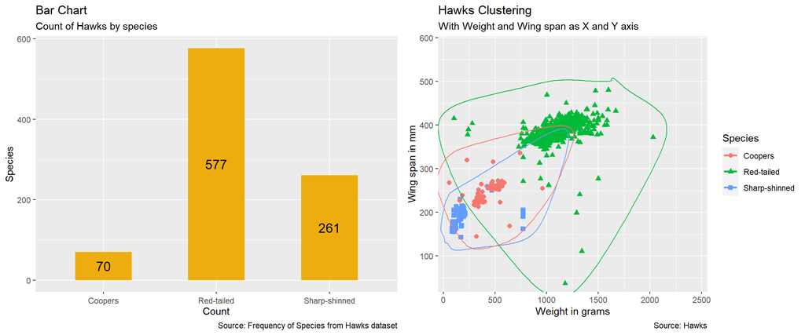

```r
##see variable we are trying to predict.
# prep frequency table
freqtable <- table(hw$Species)
df <- as.data.frame.table(freqtable)


# Plot
p1 <- ggplot(df, aes(Var1, Freq, label = Freq))+
  geom_bar(stat="identity", width = 0.5, fill="darkgoldenrod2") +
  labs(title="Bar Chart",
       subtitle="Count of Hawks by species",
       caption="Source: Frequency of Species from Hawks dataset",
       x = "Count",
       y = "Species") +
  theme(axis.text.x = element_text(angle=0, vjust=0.6))+
  geom_text(size = 5, position = position_stack(vjust = 0.5))


df_ss <- hw1[hw1$Species == "Sharp-shinned", ]
df_rt <- hw1[hw1$Species == "Red-tailed", ]
df_c  <- hw1[hw1$Species == "Coopers", ]

p2 <- ggplot(hw1, aes(Weight, Wing, col=Species)) +
  geom_point(aes(shape=Species), size=2) +   # draw points
  labs(title="Hawks Clustering",
       subtitle="With Weight and Wing span as X and Y axis",
       caption="Source: Hawks",
       x = "Weight in grams",
       y="Wing span in mm") +
  coord_cartesian(xlim = 1.2 * c(min(hw1$Weight), max(hw1$Weight)),
                  ylim = 1.2 * c(min(hw1$Wing), max(hw1$Wing)))+   # change axis limits
  geom_encircle(data = df_ss, aes(x=Weight, y=Wing)) +   # draw circles
  geom_encircle(data = df_rt, aes(x=Weight, y=Wing)) +
  geom_encircle(data = df_c, aes(x=Weight, y=Wing))

par(mfrow=c(1,2), mar=c(4,4,1,1), oma=c(0.5,0.5,1,1))


grid.arrange(p1, p2, ncol = 2)
```

# Machine learning algorithms

Before we dive into the different models, it is important to explain how we will compare the models. The accuracy will be reported, but given the large class imbalance (i.e. the bar chart above) other indicies are better. We will use Kappa as it takes into account random chance. That is to say, with large class imbalance the model could guess Red-tailed hawks and would have an accuracy of 63%, which is poor but is better than random chance. There are other fit indicies we could use - Sensitivity, specificity, Precision, F, to name a few - but these are more apt for other types of classification. For instance, they would be good for cancer detection, churn rates, or search engine models as the first two examples have we could weight the value of a true positive & false negatives, while search engine models allow for a wide breadth or results, thus trying to avoid false positives (i.e. removing irrelevant search results).

### Kappa

To understand Kappa, it is a value that ranges from 0 to 1 with following interpretation:

Poor agreement = less than 0.20

Fair agreement = 0.20 to 0.40

Moderate agreement = 0.40 to 0.60

Good agreement = 0.60 to 0.80

Very good agreement = 0.80 to 1.00

A Kappa close to 1 indicates the best fitting model for the data.

## One Rule Learner

First is the One rule learner, which is comes up with one rule to classify the species of hawks. It is a very simple algorithm that is used as our baseline. In addition it provides a good heuristic for what feature may be important.

From the model

```r
hw_1R <- OneR(Species ~ .,data = hw1) #here we are looking at all the features (represented by "." and how they relate to the type of species of hawk
# hw_1R
hw_1R_pred <- predict(hw_1R, hw1)
# table(actual = hw$Species, predicted = hw_1R_pred)

oner <- confusionMatrix(hw_1R_pred, hw$Species)
a1 <- round(((oner[["overall"]][["Accuracy"]])*100), 2)
k1 <- round(oner[["overall"]][["Kappa"]], 3)
```

### One rule learner output

We see the accuracy is 97.8% but this could be due to chance. As such, we see the Kappa is 0.957 suggesting our baseline model has good classification of the data.

### Drawback of One rule learner

The downfall of the One rule learner algorithm is that is does not split that data into training, validation, & test data sets. In other words, the data models all the data we have and we cannot know how it will perform on future, unseen data. It only creates one rule to categorize all the data we have. As such, all the following algorithms split the data into training, validation and test data sets.

## Split the data

The original data set has 908 hawks, the data will be split in a training data set with 80% of the data and the validation and test data sets will each 10% of the data. THis gives am 80/10/10 split. The reason for splitting the data into 3 is we can first train the algorithms on the training data set, then see how they perform on the validation data set. In addition, we can tune parameters to determine how they influence model fit. After which, we will determine which algorithm best classifies the data. Lastly, we can test the algorithm on completely unseen data to give us an idea for how it will perform in the future for any new data we will encounter.

## K-nearest neighbor (KNN)

For KNN models, we have to standardize the hawk characteristics to put them on the same scale (i.e. before scaling, Wing span was in mm and Weight was in grams), which helps optimize the algorithm

```r
##Getting the labels
RNGversion("4.0.3"); set.seed(123) ##123 is arbitrary
train_sample <- sample(908, 817)
val_knn_sample <- sample(817, 726)
hw_knn_test_labels <- hw1[-train_sample,1] # gets 91 from main df
train_sample1<- hw1[train_sample,1:5] # gets remaining 817 from main df
hw_knn_val_labels <- train_sample1[-val_knn_sample,1] # gets 91 from remaining 817
hw_knn_train_labels <- train_sample1[val_knn_sample,1] # gets 726 hawks

#Scale
hw_knn <- hw1[,c(2:5)]
hw_knn <- scale(hw_knn)
hw_knn <- as.data.frame(hw_knn)

#get the test df
hw_knn_test  <- hw_knn[-train_sample, ]
# Validation df
train_sample2<- hw_knn[train_sample,]
hw_knn_val <- train_sample2[-val_knn_sample, ]
#get the train df
hw_knn_train  <- train_sample2[val_knn_sample, ]



######k-nn training
hw_knn_val_pred <- knn(train = hw_knn_train,
                    test = hw_knn_val,
                    cl = hw_knn_train_labels,
                    k = 3)

###evaluate model
# CrossTable(x = hw_knn_val_labels, y = hw_knn_val_pred,
#            prop.chisq = FALSE)

k <- confusionMatrix(hw_knn_val_pred, hw_knn_val_labels)

k2 <- round(k[["overall"]][["Kappa"]], 3) # gives Kappa
# e <- as.data.frame(k[["byClass"]]) # to get other indicies
```

### KNN output

The Kappa for the KNN model is 0.954, which is slightly worse than our baseline One rule learner model that had a Kappa of 0.957. This indicates the KNN model may not be the best algorithm for the data. As such, we’ll test a decision tree next.

## Decision tree

```r
####split data into training and test sets. 90% for training and 10% for test. dont need to standardize
RNGversion("4.0.3"); set.seed(123) ##123 is arbitrary
train_dt_sample <- sample(908, 817) # here we randomly choose 817 numbers from number 1-908
##get the training df
hw_dt_train <- hw1[train_dt_sample, ]
#get the test df
hw_dt_test  <- hw1[-train_dt_sample, ]

val_dt_sample <- sample(817, 726) # here we randomly choose 654 numbers from number 1-817
##get the validation df
hw_dt_val  <- hw_dt_train[-val_dt_sample, ]
#get the train df
hw_dt_train <- hw_dt_train[val_dt_sample, ]

#This is comparing the 4 columns of attributes to the target variable(species)
hw_dt_model <- C5.0(hw_dt_train[2:5], hw_dt_train$Species)
# hw_dt_model # we see there are 4 predictors and has 11 branches
# summary(hw_dt_model)



##evaluate the model on the test data
hw_dt_pred <- predict(hw_dt_model, hw_dt_val)

k <- confusionMatrix(hw_dt_pred, hw_dt_val$Species)

k3 <- round(k[["overall"]][["Kappa"]], 3)
```

### Decision tree output

The Kappa for the Decision tree model is 0.954, which is close, but still slightly worse than our baseline One rule learner model that had a Kappa of 0.957. Next I boosted the decision tree to see if this can increase the Kappa, thus the classification.

## Boosted Decision tree

```r
#adaptive Boost the model
start_time <- Sys.time()
hw_model10 <- C5.0(hw_dt_train[2:5], hw_dt_train$Species, trials = 10)
#evaluate the boosted model
hw_pred10 <- predict(hw_model10, hw_dt_val)
end_time <- Sys.time()
t1 <- round(end_time - start_time, 3)

# hw_model10
# summary(hw_model10)

k <- confusionMatrix(hw_pred10, hw_dt_val$Species)

k4 <- round(k[["overall"]][["Kappa"]], 3)
```

### Boosted decision tree output

The Kappa for the Boosted decision tree model is 0.977, and this is a much better fit compared to the baseline model that had a Kappa equal 0.957. The Boosted decision tree is currently the most accurate model in classifying the species of hawks.

## Support Vector Machines (SVM)

```r
RNGversion("4.0.3"); set.seed(123) ##123 is arbitrary
train_sample <- sample(908, 817) # here we randomly choose 817 numbers from number 1-908
##get the training df
hw_train <- hw1[train_sample, ]
#get the test df
hw_test  <- hw1[-train_sample, ]

val_sample <- sample(817, 726) # here we randomly choose 654 numbers from number 1-817
##get the validation df
hw_val  <- hw_train[-val_sample, ]
#get the train df
hw_train <- hw_train[val_sample, ]


start_time <- Sys.time()
#training model  with a "vanilladot" kernal which is a linear kernal
hw_classifiervd <- ksvm(Species ~ ., data = hw_train,
                        kernel = "vanilladot")
#predict allows us to see how the model does on the test data
hw_predictionsvd <- predict(hw_classifiervd, hw_val)
end_time <- Sys.time()
t2 <- round(end_time - start_time, 3)


#hw_classifiervd

k <- confusionMatrix(hw_predictionsvd, hw_val$Species)

k5 <- round(k[["overall"]][["Kappa"]], 3)
```

### SVM with vanilla dot kernal output

The Kappa for the Boosted decision tree model is 0.977, and this is an identical fit to the boosted decision tree. For fun though I tried a different kernal to see if we can tune some parameters to increase the accuracy. The next algorithm is and SVM with the rbfdot kernal. Additionally, I examined if we could alter the cost function in the algorithm to influence the model fit.

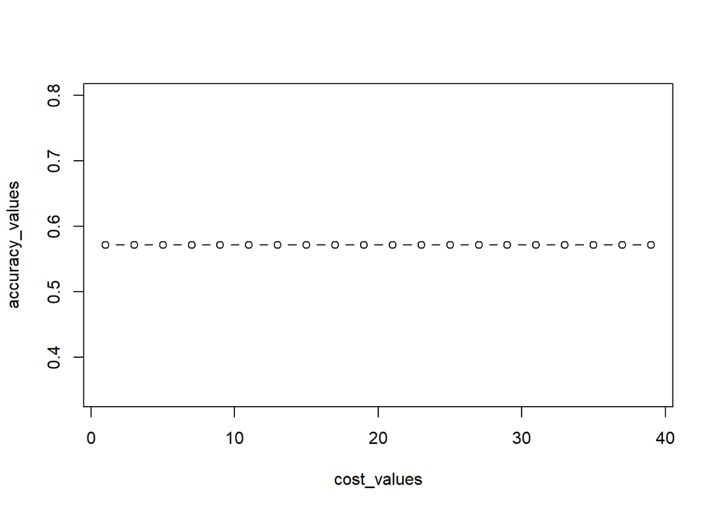

```r
####Using a different kernel, rbfdot
start_time <- Sys.time()
hw_classifierrbf <- ksvm(Species ~ ., data = hw_train,
                         kernel = "rbfdot")

#evaluate the model
hw_predictionsrbf <- predict(hw_classifierrbf, hw_val)
end_time <- Sys.time()
t3 <- round(end_time - start_time, 3)

#hw_classifierrbf

cost_values <- c(1, seq(from = 1, to = 40, by = 2))

accuracy_values <- sapply(cost_values, function(x) {
  set.seed(12345)
  m <- ksvm(Species ~ ., data = hw_train,
            kernel = "rbfdot", C = x)
  pred <- predict(m, hw_test)
  agree <- ifelse(pred == hw_val$Species, 1, 0)
  accuracy <- sum(agree) / nrow(hw_test)
  return (accuracy)
})

plot(cost_values, accuracy_values, type = "b")
```

```r
###based on this, the cost value makes no difference for the "rbfdot" kernel


k <- confusionMatrix(hw_predictionsrbf, hw_val$Species)

k6 <- round(k[["overall"]][["Kappa"]], 3)
```

### SVM with rbfdot kernal output

The Kappa for the SVM with rbfdot kernal model is 0.977, which is the same as our SVM with rbfdot kernal model and the Boosted decision tree model that both had a Kappa of 0.977. In addition, the plot shows different costs values that could be used to tune the model. For this data set the cost value has no influence in the accuracy of classification. This makes sense as a Cost value is more apt in data that is non-linear as the cost value alters the classification from trying to maximize the margin between the classes and instead tries to minimize the cost value.

### Comparing models

Given that we have 3 algorithms that have the same accuracy for classifying the species of hawks. As such, to pick what model we want to use on the test training data set, there are few factors we can consider. One is the time it takes to run each model. The Boosted decision tree took 0.03 seconds, SVM with vanilla kernal took 0.614 seconds, and SVM with rbfdot took 0.677 seconds. The other aspect is interpretability of each model. The boosted decision tree is intuitive compared to SVM models, which transforms the data into a feature space, then finds a hyperplane that best separates(classifies) the data. With the current data set, any of these algorithms could be used, but if our model was prone to overfitting we may want to choose an SVM algorithm. For this example we will use the Boosted decision tree because it is the fastest of the model.

### Final algorithm

```r
#evaluate the boosted model on the test data
hw_pred10_test <- predict(hw_model10, hw_dt_test)


# hw_model10 # we see there are 4 predictors and 10 iterations, and average tree is 6.5
# summary(hw_model10)

k <- confusionMatrix(hw_pred10_test, hw_dt_test$Species)

k7 <- round(k[["overall"]][["Kappa"]], 3)
af <- (round(k[["overall"]][["Accuracy"]], 2)) * 100
```

The Boosted decision tree performs very well on the test data set. In fact, Kappa is perfect 1. In addition below we can visualize the algorithm. The model uses the hawks Culmen (beak length) and Hallux (talon length) to classify the species of hawks. The nodes at the bottom indicate the likelihood of a species being classified based on decisions in the model. For instance, in Node 3, there were 206 hawks classified as Sharp-shinned because first the bird had a Culmen less than or equal to 20 mm and a hallux less than or equal to 15.7 mm.

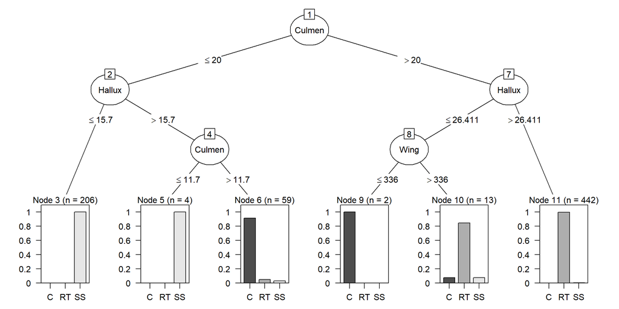

```r
# Visualize the decision tree
hw_dt_train$Species <- factor(hw_dt_train$Species, labels = c("C", "RT", "SS"))
plot(hw_model10)
```

Note: “C” = Coopers; “RT” = Red-tailed; “SS” = Sharp-shinned

# Conclusion

After running the different models the Boosted decision tree was chosen as the most accurate and efficient model for the given data. On the test data set the algorithm had a Kappa of 1 and an accuracy of 100%. From the model it was seen that the Culmen and Hallux are the main features used to classify the species of hawks. This makes sense because attempting to identify a hawk by eye the average person typically uses the size (weight and wing span) of the bird, yet the algorithm and wildlife biologists use other features to identify hawks.

### Future directions

The next step could be to ask questions, such as are there more Adult Cooper’s hawks than the other hawks? Then we can start to wonder why this may be the case and what we can do help the survival of these animals.

Disclaimer: I know very little about birds. I could not tell the difference between hawks or falcons and probably the only large bird I could identify is a bald eagle. But they all are gorgeous animals.

Jump to Top